# Team.Rmd

Julia Lundstrum, Nikole Slinger, and Zack Larson

## Lab 3

### Part 1

Initial data cleaning up:

```r
library(tidyverse)
```

```r
library(ggplot2)
library(dplyr)
library(readxl)
data <- readxl::read_xls('./GSS.xls')
# This is needed to easily handle column names in the future
names(data)<-str_replace_all(names(data), c(" " = "."))
colnames(data)
```

```
## [1] "Gss.year.for.this.respondent"     "Respondent.id.number"
## [3] "Number.of.hours.worked.last.week" "Marital.status"
## [5] "Highest.year.of.school.completed" "Political.party.affiliation"
## [7] "Belief.in.life.after.death"       "General.happiness"
## [9] "Ballot.used.for.interview"
```

### Part 2

#### Problem 1.

The marital status is somewhat correlated with the person’s marital status as shown in the graph and numerical summary below. It shows us the average number of years completed per marital status and it shows that people in the ‘Never married’ group have the highest education level on average among those who answered the question, at 13.4 years. This is probably because those who have never been married likely have more time to complete more years of schooling, while those who are married do not as much time. People in the ‘Married’ and ‘Divorced group have a very similar education level, at 13.0 and 13.1 respectively. We found it interesting that the people in the ’Separated’ and ‘Widowed’ group have a lower average education level than the other groups. This could possibly be because they are older (as widows are most likely older and had less of a need for more schooling years ago) or maybe for some other reason.

```r
# changing to numeric column
data$Highest.year.of.school.completed <- as.numeric(as.character(data$Highest.year.of.school.completed))
# This is to get the average 'highest year of school completed' per marital status
mar <- data %>% group_by(Marital.status) %>%
  summarize(mean = mean(Highest.year.of.school.completed,na.rm = TRUE)) %>%
  arrange(desc(mean))
mar
```

```
## # A tibble: 7 x 2
##   Marital.status  mean
##   <chr>          <dbl>
## 1 No answer       15.5
## 2 Never married   13.4
## 3 Divorced        13.1
## 4 Married         13.0
## 5 Separated       11.9
## 6 Widowed         11.2
## 7 <NA>           NaN
```

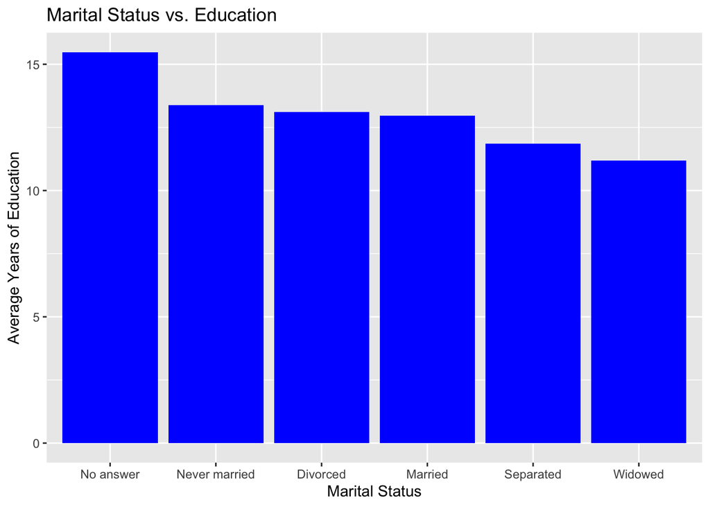

```r
p <- ggplot(subset(mar, !is.na(Marital.status)), aes(x=reorder(Marital.status, -mean), weight=mean)) + geom_bar(fill = "blue") + ggtitle("Marital Status vs. Education") + ylab("Average Years of Education") + xlab("Marital Status")
p
```

#### Problem 2.

Data frame structure for the Better Educated printed below.

```r
# We filter for the people who have the associated marital status and more years of school completed than the average of their marital status group
betterEducated <- data %>%
    group_by(Marital.status) %>%
    filter(Highest.year.of.school.completed > mean(Highest.year.of.school.completed, na.rm=TRUE)) %>%
    ungroup()
str(betterEducated)
```

```
## tibble [30,714 × 9] (S3: tbl_df/tbl/data.frame)
##  $ Gss.year.for.this.respondent    : num [1:30714] 1972 1972 1972 1972 1972 ...
##  $ Respondent.id.number            : num [1:30714] 1 4 6 8 11 16 17 19 20 23 ...
##  $ Number.of.hours.worked.last.week: chr [1:30714] "Not applicable" "Not applicable" "Not applicable" "Not applicable" ...
##  $ Marital.status                  : chr [1:30714] "Never married" "Married" "Never married" "Never married" ...
##  $ Highest.year.of.school.completed: num [1:30714] 16 17 14 16 13 14 14 17 14 13 ...
##  $ Political.party.affiliation     : chr [1:30714] "Ind,near dem" "Not str democrat" "Ind,near dem" "Ind,near dem" ...
##  $ Belief.in.life.after.death      : chr [1:30714] "Not applicable" "Not applicable" "Not applicable" "Not applicable" ...
##  $ General.happiness               : chr [1:30714] "Not too happy" "Not too happy" "Pretty happy" "Not too happy" ...
##  $ Ballot.used.for.interview       : chr [1:30714] "Not applicable" "Not applicable" "Not applicable" "Not applicable" ...
```

#### Problem 3.

Marital status seems to have some relation to a person’s general happiness. Looking at the data of people who are considered ‘Pretty happy’ or ‘Very happy’, we found that the marital group with the most amount of people in the highest happiness levels is the ‘Married’ group, with 29,342 people. Both the graph and the count confirm this finding as well as give us insight to the other marital groups as well. It looks like the people in the ‘Separated’ group are among the least happy, with there only being 1,487 people. In addition, it shows us that ‘Never married’ people are generally happier than both ‘Divorced’ and ‘Widowed’ people. A final note is that there appears to be more ‘Pretty happy’ people than ‘Very happy’ people in general. We are disregarding the ‘No answer’ group because it doesn’t tell us any real life data.

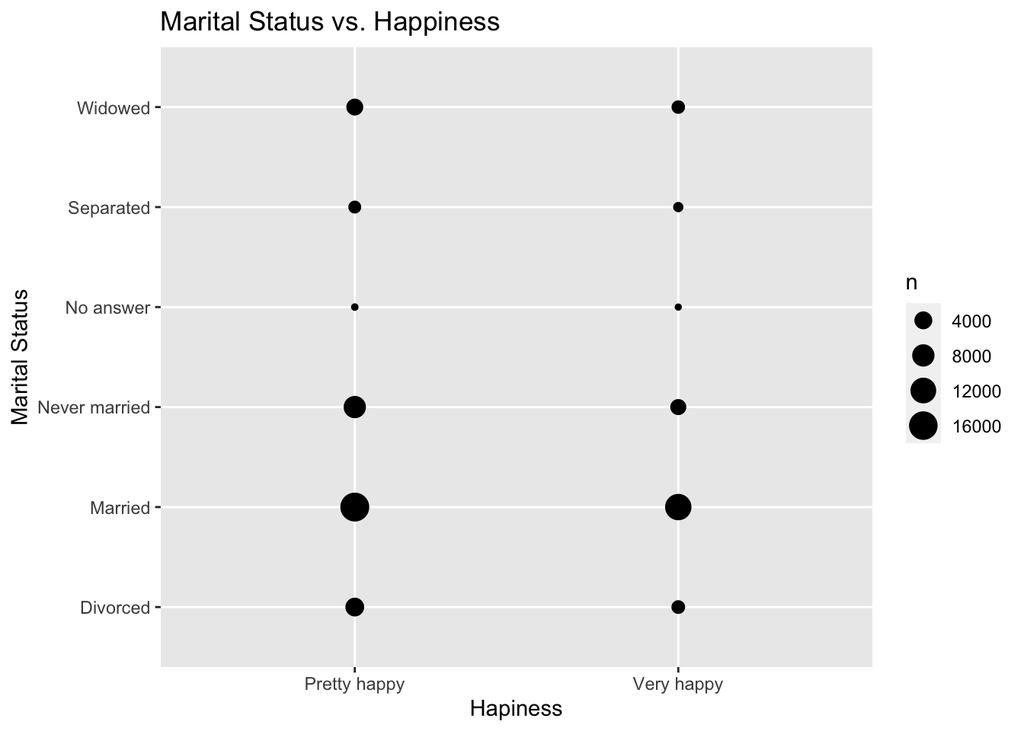

```r
# creating date frame of desired happiness level
happiness <- filter(data, General.happiness == 'Very happy' | General.happiness == 'Pretty happy')

p <- ggplot(happiness, aes(x = General.happiness, y = Marital.status)) + geom_count()
p + ggtitle('Marital Status vs. Happiness') + xlab('Hapiness') + ylab('Marital Status')
```

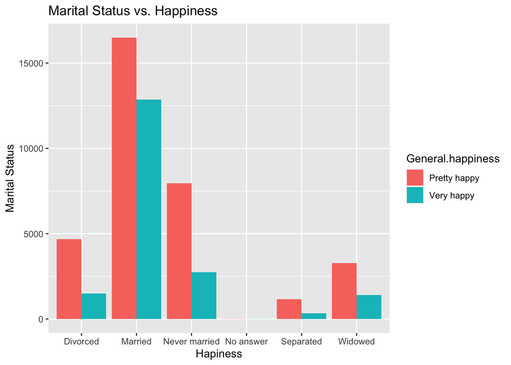

```r
p <- ggplot(happiness, aes(x = Marital.status, fill = General.happiness)) +
  geom_bar(position = 'dodge')
p + ggtitle('Marital Status vs. Happiness') + xlab('Hapiness') + ylab('Marital Status')
```

```r
tail(names(sort(table(happiness$Marital.status))), 1)
```

```
## [1] "Married"
```

```r
# getting numerical count
happiness %>% count(Marital.status)
```

```
## # A tibble: 6 x 2
##   Marital.status     n
## * <chr>          <int>
## 1 Divorced        6180
## 2 Married        29342
## 3 Never married  10686
## 4 No answer         16
## 5 Separated       1487
## 6 Widowed         4675
```

#### Problem 4.

Political party affiliation does not seem to have much of an effect on the relationship between the marital status and general happiness of a person. In the graphs and numerical summaries, we found that regardless of political party, those in the ‘Married’ group were still the most popular marital status for happy people and separated people were still among the least happy. Not only that, it looks that the amount of people (based on dot size) is roughly the same across the x-axis for each group.

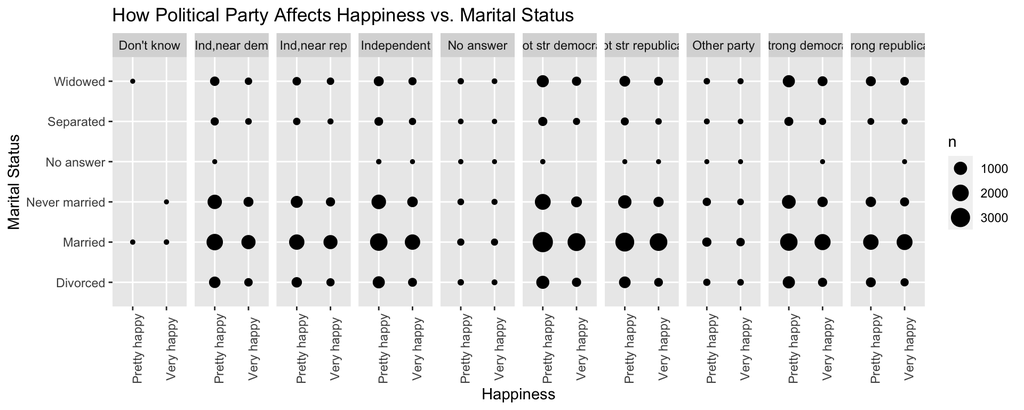

```r
# creating political party data frame
party <- data %>% group_by(Political.party.affiliation) %>%
  filter(General.happiness == "Very happy" | General.happiness == "Pretty happy")

# visual plot for party vs happiness relationship
p <- ggplot(party, aes(x = General.happiness, y = Marital.status)) + geom_count() +
  facet_grid(cols = vars(Political.party.affiliation)) +
  theme(axis.text.x = element_text(angle = 90))
p + ggtitle('How Political Party Affects Happiness vs. Marital Status') +
  xlab('Happiness') + ylab('Marital Status')
```

```r
# This shows the most popular party affiliation among 'happy' people
tail(names(sort(table(party$Political.party.affiliation))), 1)
```

```
## [1] "Not str democrat"
```

```r
# getting numerical count
party %>% count(Marital.status)
```

```
## # A tibble: 56 x 3
## # Groups:   Political.party.affiliation [10]
##    Political.party.affiliation Marital.status     n
##    <chr>                       <chr>          <int>
##  1 Don't know                  Married            6
##  2 Don't know                  Never married      1
##  3 Don't know                  Widowed            1
##  4 Ind,near dem                Divorced         803
##  5 Ind,near dem                Married         3203
##  6 Ind,near dem                Never married   1670
##  7 Ind,near dem                No answer          1
##  8 Ind,near dem                Separated        193
##  9 Ind,near dem                Widowed          378
## 10 Ind,near rep                Divorced         589
## # … with 46 more rows
```

#### Problem 5.

Education is somewhat related to the person’s marital status as shown in the graphs and numerical summaires below. The first graph shows the average number of years completed in each marital status group, which shows that people in the ‘Never married’ group have the highest average (once again we are disregarding the ‘No answer’ group). This explains to us once again that the ‘Never married’ people probably have more time to complete more years of school while the people in the ‘Married’ group don’t have as much, as they might be focused on their relationship or families. It is interesting to note that the people in the ‘Separated’ and ‘Widowed’ group have a slightly lower average than the other marital statuses. This could be because they are older (less demand for more schooling years ago) or for some other reason unrelated to the variables.

In the second graph, this shows us where the majority of people associate themselves for these 2 values. Looking at each marital status we can see the distribution of school years completed. For example, among those in the ‘Married’ group, the most popular range of year of school completed are between 12 and 16 years, where as for people in the ‘Widowed’ group, the most popular range of year of school completed is between 8 and 14 years.

Finally, we can look at the numerical summaries to get more specific measurements from the data. If we filter for people who have over 13 years of school completed (which we considered as higher educated), we found that ‘Married’ is the most popular marital status among people with over 13 years of school completed, telling us that there is likely a correlation between being married and having a high education. We can also look at the specific average values for education level per marital status, and we found that once again that the ‘Never married’ group has the highest average education at 13.4 years and the ‘Widowed’ group has the lowest at 11.2 years.

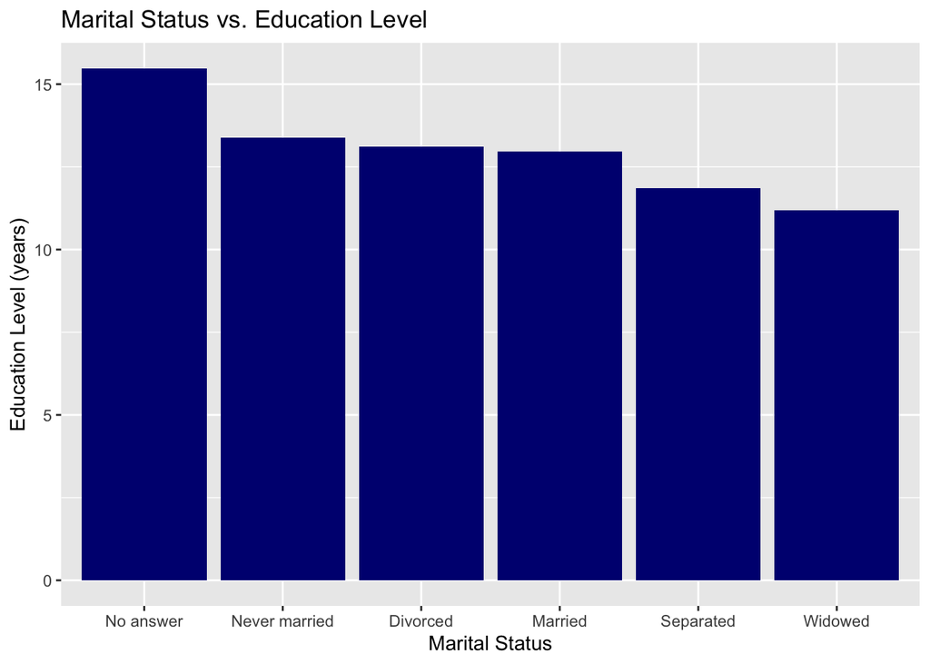

```r
# visual plots for marital status vs. education
p <- ggplot(subset(mar, !is.na(Marital.status)), aes(x=reorder(Marital.status, -mean), weight=mean)) + geom_bar(fill = "navy")
p + ggtitle('Marital Status vs. Education Level') +
  xlab('Marital Status') + ylab('Education Level (years)')
```

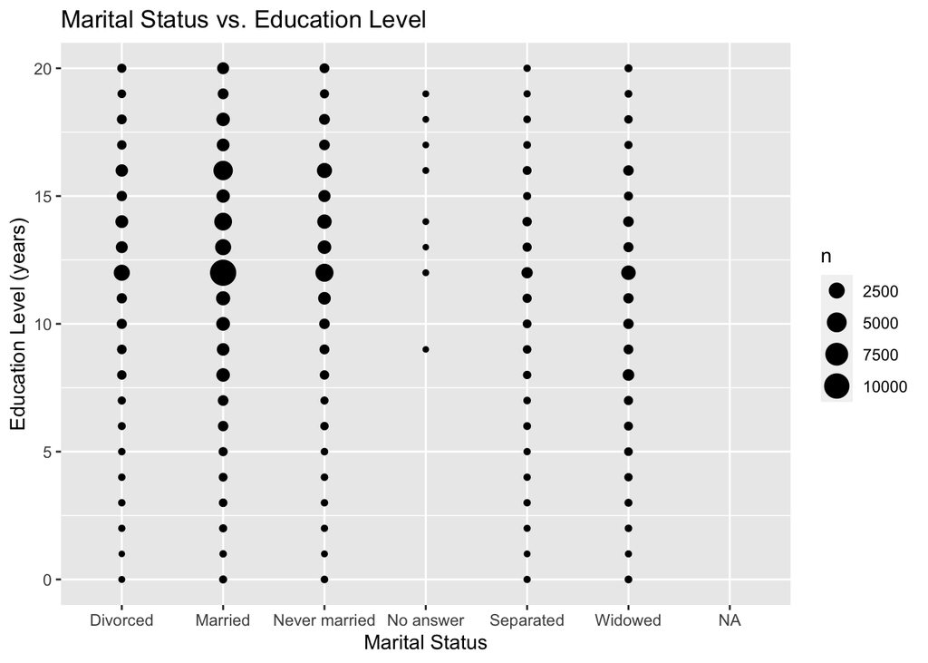

```r
p <- ggplot(data, aes(x = Marital.status, y = Highest.year.of.school.completed)) +
  geom_count()
p + ggtitle('Marital Status vs. Education Level') +
  xlab('Marital Status') + ylab('Education Level (years)')
```

```r
# numerical summaries: marital group with highest education and mean educations
highEducation <- data %>% group_by(Marital.status) %>%
  filter(Highest.year.of.school.completed > 13)
tail(names(sort(table(highEducation$Marital.status))), 1)
```

```
## [1] "Married"
```

```r
data %>% group_by(Marital.status) %>%
  summarize(mean = mean(as.numeric(Highest.year.of.school.completed), na.rm=TRUE)) %>%
  arrange(desc(mean))
```

```
## # A tibble: 7 x 2
##   Marital.status  mean
##   <chr>          <dbl>
## 1 No answer       15.5
## 2 Never married   13.4
## 3 Divorced        13.1
## 4 Married         13.0
## 5 Separated       11.9
## 6 Widowed         11.2
## 7 <NA>           NaN
```

#### Problem 6.

We evaluated two potential relations: Number of Work Hours a Week VS. General Happiness and Belief in Life After Death VS. General Happiness. For the first relationship, we looked at the average number of hours worked for each category in ‘General happiness’ and compared them to each other to see which level of happiness tends to work more or less. Overall, the averages were all pretty close (all within the range of 40-46 hours a week). However, out of all of the people who directly answered the question, the group who worked the most amount of hours, on average, were the most happiest. Meanwhile, the people in the ‘Not happy’ group definitely showed that they worked the least amount. This could possibly be that because they don’t have a job or are unemployed, they are unhappy. Another explanation, looking from a different perspective, may be that those who have found a job or career that they are truly interested in find happiness in their work, so they work more hours and are more happier.

```r
# happiness vs. work
data$Number.of.hours.worked.last.week <- as.numeric(as.character(data$Number.of.hours.worked.last.week))
# numerical summary
group_by(data, General.happiness) %>%
  summarize(m = mean(Number.of.hours.worked.last.week,na.rm = TRUE))
```

```
## # A tibble: 7 x 2
##   General.happiness     m
## * <chr>             <dbl>
## 1 Don't know         45.6
## 2 No answer          43.0
## 3 Not applicable     42.0
## 4 Not too happy      39.9
## 5 Pretty happy       41.3
## 6 Very happy         41.5
## 7 <NA>              NaN
```

```r
# This shows the most popular number of hours worked in a week among 'happy' people
tail(names(sort(table(data$Number.of.hours.worked.last.week))), 1)
```

```
## [1] "40"
```

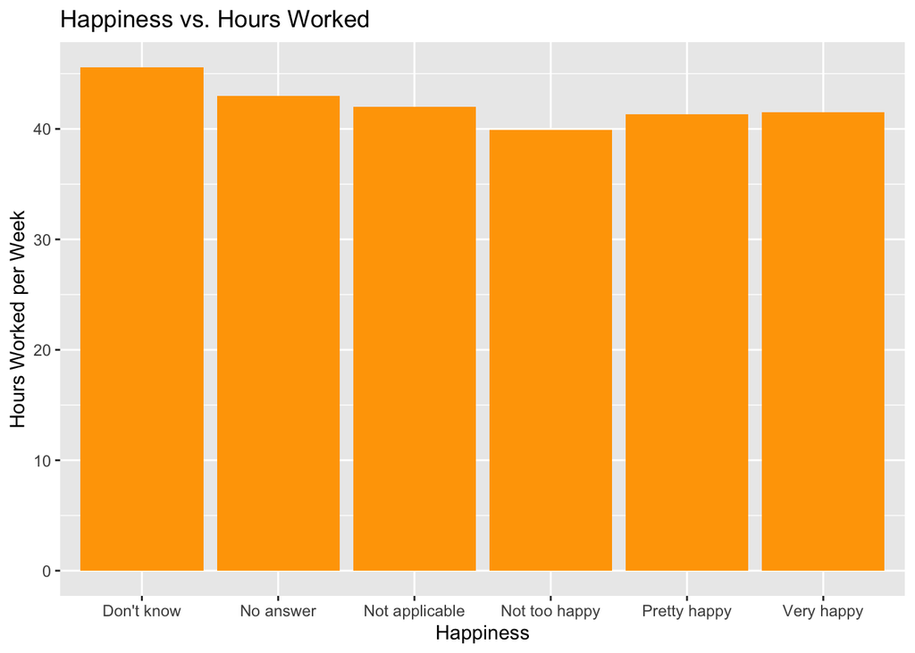

```r
# graphical summary
p <- ggplot(subset(data, !is.na(General.happiness)), aes(x = factor(General.happiness), y = Number.of.hours.worked.last.week)) +
  stat_summary(fun = "mean", geom = "bar", fill = "orange")
p + ggtitle('Happiness vs. Hours Worked') +
  xlab('Happiness') + ylab('Hours Worked per Week')
```

Next, we evaluated the potential correlation between one’s belief in life after death and their overall happiness. For this, we looked at the frequency and distributions of a person’s level of happiness and compared it to their beliefs in what happens to life after death. We found that the slight majority of people surveyed said that they did believe in life after death and that they were also mostly ‘Pretty happy’ or ‘Very happy’. People who said ‘Yes’ (there is life after death) were also more likely to be ‘Not happy’, but we believe that’s due to how popular the vote for ‘Yes’ was. Looking at the sizes of ‘Happy’ compared to ‘Not happy’ show that the ratio of ‘Happy’ and ‘Not happy’ for ‘Yes’ and ‘No’ people are pretty close but with a slight edge to ‘Very happy’ people who believe in life after death. This group showed more people than other ratios of happiness. Finally, when looking at the filled bar chart, we can see that the distribution of the different happiness levels for those who answered ‘Yes’, ‘No’, and ‘Don’t know’ are very similar, which leads us to the conclusion that there is little correlation between a person’s beliefs and their general happiness.

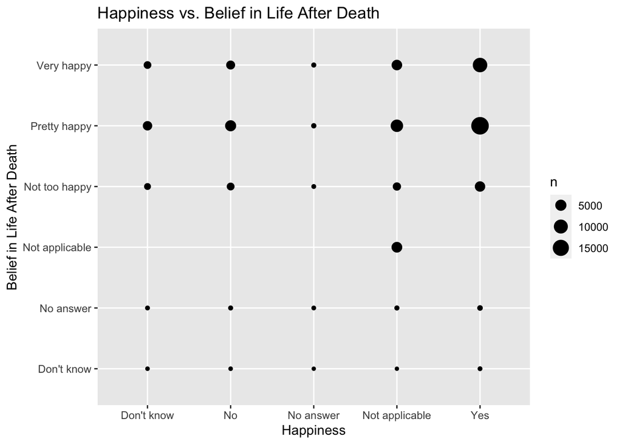

```r
# removing all NA answers
belief <- data %>% filter((Belief.in.life.after.death != 'NA'))

# happiness vs. belief
p <- ggplot(belief, aes(x = Belief.in.life.after.death, y = General.happiness)) + geom_count()
p + ggtitle('Happiness vs. Belief in Life After Death') +
  xlab('Happiness') + ylab('Belief in Life After Death')
```

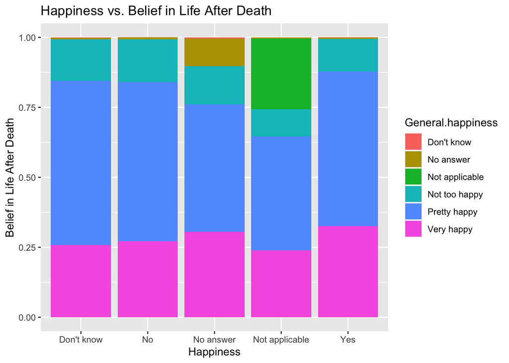

```r
# bar chart of happiness vs. belief
p <- ggplot(belief, aes(x = Belief.in.life.after.death, fill = General.happiness)) +
  geom_bar(position = 'fill')
p + ggtitle('Happiness vs. Belief in Life After Death') +
  xlab('Happiness') + ylab('Belief in Life After Death')
```

```r
# This shows the most popular belief among 'happy' people
tail(names(sort(table(data$Belief.in.life.after.death))), 1)
```

```
## [1] "Yes"
```